# Lab 1

ECOL 620 - Applications in Landscape Ecology

George Woolsey

23 January, 2023

# Setup

```r
# bread-and-butter
library(tidyverse)
library(lubridate)
library(viridis)
library(scales)
library(latex2exp)
# visualization
library(ggrepel)
library(cowplot)
library(kableExtra)
# spatial analysis
library(USAboundaries)
library(maps) # maps::map_data()
library(sf)
library(mapview) #Interactive maps
library(leafpop) #map html popup
```

# Rules

1. Using the provided R Markdown template, answer all questions and show your R code where necessary. Note, some questions are just plain text written answers.
2. Complete your assignment using the R markdown file and submit individual assignments to Canvas. Knit your script and submit an .html file on Canvas. Please use the following naming convention: lab1_firstname_lastname.html (ex. lab1_kyle_horton.html). Note, I will not grade labs in any other format.

# Question 1

Briefly describe (1-2 sentences) what each of the following functions achieve. All of these functions are seen throughout the Lab #1 example code. Use complete sentences (1 pt each).

- `c()` defines a vector to store a list of values.
- `geom_point()` is from the `ggplot2` package and is used to create a scatter plot of points.
- `geom_smooth()` is from the `ggplot2` package and is used to create a smoothed line plot of data using specified method (e.g.. linear, loess)
- `rep()` replicates value(s) a specified number of times.
- `filter()` is from the `dplyr` package and is used to filter rows in a data frame.
- `%>%()` specifies a “pipe” to pass an object to the next command for working in the `tidyverse` environment.
- `st_read()` is from the `sf` package, reads spatial data into R environment.
- `coord_sf()` is from the `ggplot2` package and is used to define the coordinate system for a plot.
- `plot_grid()` is from the `cowplot` package and is used to create a grid of multiple plots.
- `library()` loads a package into the current R environment.

# Question 2

Using the existing code from the lab, plot the contiguous United States with colors representing the area of each state. Note, area is an existing column of information within the `fact_join` data frame. Print your plot and add “Area of US States” as the title. You can follow this link to explore modify axis, legend, and plot labels:https://ggplot2.tidyverse.org/reference/labs.html. (7 pts)

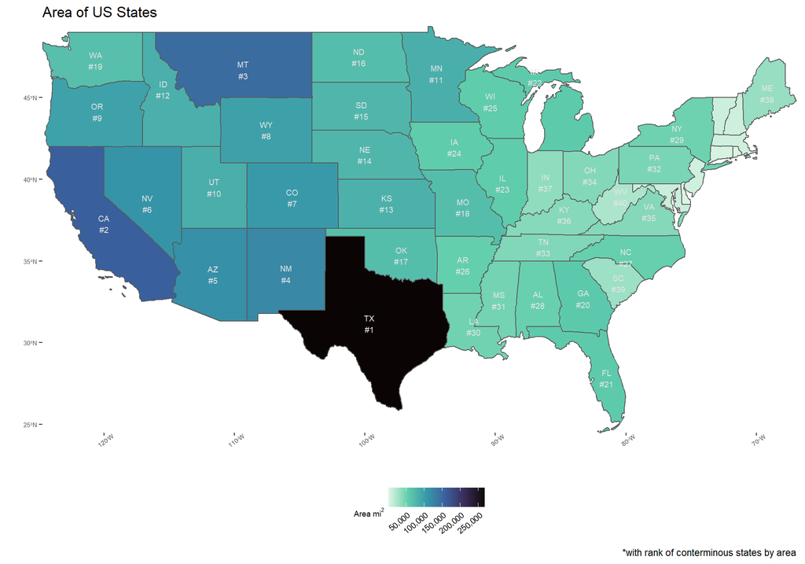

```r
# load and combine tabular data
states_tabular <- data.frame(
    name = datasets::state.name
    , state_area_mi2 = datasets::state.area
    , state_division = datasets::state.division
  ) %>%
  dplyr::mutate(
    join_name = toupper(name)
    , state_area_km2 = state_area_mi2 * 2.58999
    , region = as.character(state_division)
  )
# combine tabular data with spatial data
states_spatial <- USAboundaries::us_states() %>%
  dplyr::mutate(
    join_name = toupper(state_name)
    , shape_area_km2 = as.numeric(sf::st_area(.)) / 1e+6
    , shape_area_mi2 = as.numeric(sf::st_area(.)) / 2.59e+6
  ) %>%
  dplyr::inner_join(states_tabular, by = c("join_name"="join_name"), keep = FALSE) %>%
  dplyr::filter(
    !toupper(state_name) %in% c("ALASKA", "HAWAII")
  ) %>%
  dplyr::mutate(
    area_rank = dplyr::min_rank(-state_area_km2)
    , map_label = ifelse(area_rank < 41,  paste0(stusps, "\n#", area_rank), "")
  )

# create chloropleth of state area
ggplot(data=states_spatial) +
  geom_sf(mapping = aes(fill = state_area_mi2)) +
  geom_sf_label(
    mapping = aes(label = map_label)
    , label.size = NA
    , alpha = 0
    , size = 2.5
    , color = "gray90"
  ) +
  xlab("") +
  ylab("") +
  scale_x_continuous(expand = c(0, 0)) +
  scale_y_continuous(expand = c(0, 0)) +
  scale_fill_viridis_c(
    option = "mako", direction = -1
    , labels = scales::comma, name = latex2exp::TeX("Area $mi^2$")
  ) +
  labs(
    title = "Area of US States"
    , caption = "*with rank of conterminous states by area"
  ) +
  theme_bw() +
  theme(
    axis.text = element_text(size = 5.5)
    , axis.text.x = element_text(angle = 35)
    , panel.grid = element_blank()
    , panel.border = element_blank()
    , legend.position = "bottom"
    , legend.direction = "horizontal"
    , legend.text = element_text(angle = 40, size = 7, vjust = 1, hjust = 1)
    , legend.title = element_text(size = 7)
  )
```

# Question 3

Create two common plots using `ggplot` — the scatter plot and the bar plot. For both plots, plot the summed area (in square kilometers, currently the native units are square miles) of US states by geographic region. The necessary datasets to complete this question are already loaded into R, specially you’ll need `state.area` and `state.division`. You may also want to link these with `state.name`. For the barplot, shade the bars in your favorite color. For the scatter plot, shade the points with a unique color for each region. Use the `plot_grid` function to make a two-panel vertical plot. See the example on Canvas. (10 pts)

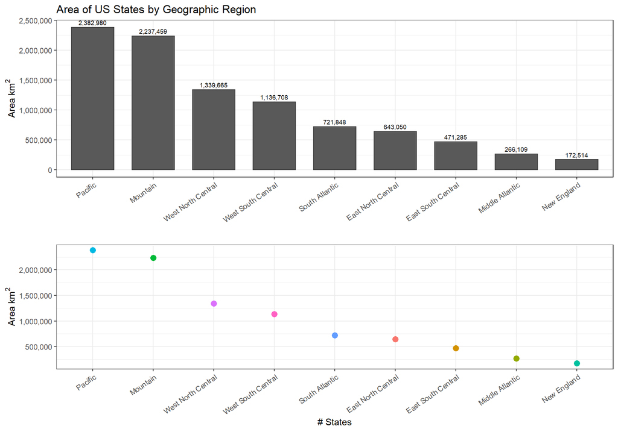

```r
# summarize data by region
dta_temp <- states_tabular %>%
  dplyr::group_by(region) %>%
  dplyr::summarise(
    area_km2 = sum(state_area_km2, na.rm = TRUE)
    , count_states = dplyr::n()
  )
# bar plot
plt_reg_area_bar <- ggplot(data = dta_temp) +
  geom_col(aes(x = reorder(region, -area_km2), y = area_km2), color = "gray23", width = 0.7) +
  geom_text(
    aes(x = reorder(region, -area_km2), y = area_km2, label = scales::comma(area_km2, accuracy = 1))
    , color = "black", size = 2.5
    , vjust = -0.5
  ) +
  labs(
      title = "Area of US States by Geographic Region"
    ) +
  xlab("") +
  ylab(latex2exp::TeX("Area $km^2$")) +
  scale_y_continuous(labels = scales::comma) +
  theme_bw() +
  theme(
    legend.position = "none"
    , axis.text.x = element_text(angle = 35, hjust = 1, vjust = 1)
  )
# scatter plot
plt_reg_area_scatter <- ggplot(data = dta_temp) +
  geom_point(aes(x = reorder(region, -area_km2), y = area_km2, color = region), size = 3) +
  xlab("# States") +
  ylab(latex2exp::TeX("Area $km^2$")) +
  scale_y_continuous(labels = scales::comma) +
  scale_fill_viridis_d(option = "turbo") +
  theme_bw() +
  theme(
    legend.position = "none"
    , axis.text.x = element_text(angle = 35, hjust = 1, vjust = 1)
  )
# combine plots vertically
cowplot::plot_grid(
  plotlist =  list(plt_reg_area_bar, plt_reg_area_scatter)
  , ncol = 1
  , rel_heights = c(1,0.8)
)
```

# Question 4

Using the existing code from the lab, map Colorado colleges and universities within the top 95th quantile of total student enrollment. Use the following line of code to add point labels. This function is in the ggrepel library, which you’ll need to install. (7 pts)

`geom_label_repel(data=NAME_OF_YOUR_FILTERED_DATA, aes(label=NAME, geometry = geometry), stat = "sf_coordinates", force=20, size=2)`

## Load Data

Load in the university data, transform to spatial, and create ranking of enrollment variable by state

```r
# read in university data
us_uni_spatial <- read.csv("../data/universities.csv") %>%
  # convert to spatial
  sf::st_as_sf(., coords = c("LON", "LAT"), crs = "+proj=longlat +datum=WGS84") %>%
  # transform to coordinate system of state data
  sf::st_transform(crs = sf::st_crs(states_spatial)) %>%
  # create ranking of enrollment variable by state
  dplyr::group_by(LSTATE) %>%
  dplyr::mutate(
    enrollment_pct_rank = dplyr::percent_rank(TOT_ENROLL)
    , INST_SIZE = as.factor(INST_SIZE)
  ) %>%
  dplyr::ungroup()
```

## Create Map

Map Colorado colleges and universities within the top 95th quantile of total student enrollment

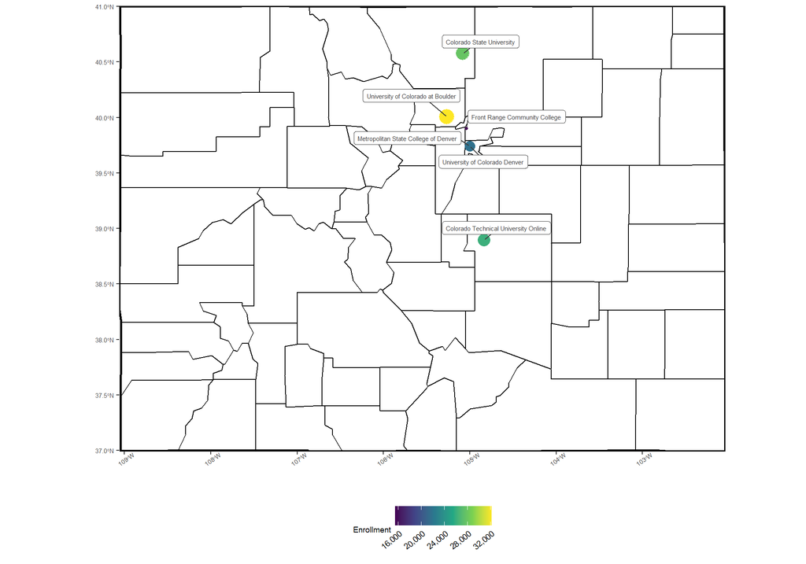

```r
# filter data
my_state <- "CO"
uni_temp <- us_uni_spatial %>%
  dplyr::filter(LSTATE==my_state) %>%
  dplyr::filter(
    enrollment_pct_rank >= 0.95
  )
# map
  ggplot() +
    geom_sf(
      data = USAboundaries::us_counties(states = my_state)
      , alpha = 0, lwd = 0.5, color = "black"
    ) +
    geom_sf(
      data = USAboundaries::us_states(states = my_state)
      , alpha = 0, lwd = 1, color = "black"
    ) +
    geom_sf(
      data = uni_temp
      , aes(size = TOT_ENROLL, color = TOT_ENROLL)
    ) +
    ggrepel::geom_label_repel(
      data = uni_temp
      , aes(label=NAME, geometry = geometry)
      , stat = "sf_coordinates"
      , force=20
      , size=2
      , color = "gray25"
      , min.segment.length = 0
    ) +
    scale_color_viridis_c(
      option = "viridis"
      , labels = scales::comma, name = "Enrollment"
    ) +
    xlab("") +
    ylab("") +
    scale_x_continuous(expand = c(0, 0)) +
    scale_y_continuous(expand = c(0, 0)) +
    theme_bw() +
    theme(
      axis.text = element_text(size = 5.5)
      , axis.text.x = element_text(angle = 35)
      , panel.grid = element_blank()
      , panel.border = element_blank()
      , legend.position = "bottom"
      , legend.direction = "horizontal"
      , legend.text = element_text(angle = 40, size = 7, vjust = 1, hjust = 1)
      , legend.title = element_text(size = 7)
    ) +
    guides(size = "none")
```

# Question 5

If you went to another university (outside of Colorado), plot that state (if in the US) and the universities that reside in that state. If you haven’t gone to another school (outside of Colorado) or you went to a school outside of the US, pick a US state where you’d like to study, post-doc, or gain employment. For this map, include a county-level shapefile (you’ll need to find this on your own) and be sure to align the coordinate reference systems (crs). Lastly, highlight your alma mater (in blue) or future university where you’d like to reside (in pink). Scale the size and color of the points by “INST_SIZE”. Put the name of the institution in the plot title. See my example, from New York on Canvas. (16 pts)

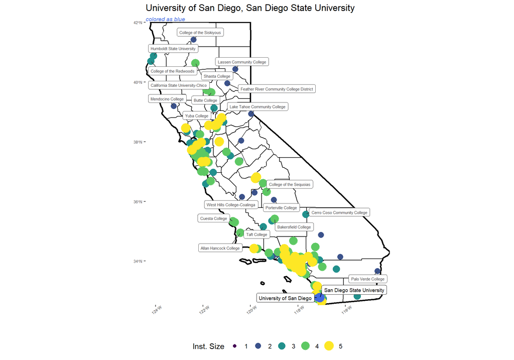

```r
my_state <- "CA"
my_uni <- c("University of San Diego", "San Diego State University")
my_pct_rnk <- 0.7
# map
  ggplot() +
    geom_sf(
      data = USAboundaries::us_counties(states = my_state)
      , alpha = 0, lwd = 0.5, color = "black"
    ) +
    geom_sf(
      data = USAboundaries::us_states(states = my_state)
      , alpha = 0, lwd = 1, color = "black"
    ) +
    geom_sf(
      data =
        us_uni_spatial %>%
          dplyr::filter(LSTATE==my_state & !NAME %in% my_uni) %>%
          dplyr::filter(
            enrollment_pct_rank >= my_pct_rnk
          )
      , aes(size = INST_SIZE, color = INST_SIZE)
    ) +
    ggrepel::geom_label_repel(
      data =
        us_uni_spatial %>%
          dplyr::filter(LSTATE==my_state & !NAME %in% my_uni) %>%
          dplyr::filter(
            enrollment_pct_rank >= my_pct_rnk
          )
      , aes(label=NAME, geometry = geometry)
      , stat = "sf_coordinates"
      , size=2
      , color = "gray25"
      , min.segment.length = 0
    ) +
   geom_sf(
      data = us_uni_spatial %>%
        dplyr::filter(LSTATE==my_state & NAME %in% my_uni)
      , aes(size = INST_SIZE)
      , color = "royalblue"
      , show.legend = FALSE
    ) +
    ggrepel::geom_label_repel(
      data = us_uni_spatial %>%
        dplyr::filter(LSTATE==my_state, NAME %in% my_uni)
      , aes(label=NAME, geometry = geometry)
      , stat = "sf_coordinates"
      , force=20
      , size=2.5
      , color = "black"
      , min.segment.length = 0
    ) +
    scale_color_viridis_d(option = "viridis") +
    labs(
      title = paste0(my_uni, collapse = ", ")
      , subtitle = "colored as blue"
      , color = "Inst. Size"
      , size = "Inst. Size"
    ) +
    xlab("") +
    ylab("") +
    scale_x_continuous(expand = c(0, 0)) +
    scale_y_continuous(expand = c(0, 0)) +
    theme_bw() +
    theme(
      axis.text = element_text(size = 5.5)
      , axis.text.x = element_text(angle = 35)
      , panel.grid = element_blank()
      , panel.border = element_blank()
      , legend.position = "bottom"
      , legend.direction = "horizontal"
      , plot.subtitle = element_text(size=8, face="italic", color="royalblue", margin = margin(0,0,0,0))
    )
```